# Modern RD practice, FRD as IV, and CG vs BH (when BH is better)

Huan Deng

October 31, 2025

> **How this document matches your slides**  
> - **RD & FRD**: we implement sharp RD, show why **FRD is a Wald/IV ratio**, and estimate it two ways (bias-corrected `rdrobust` and matching local 2SLS).  
> - **Simulated IV**: we construct **Currie–Gruber (CG)** and **Borusyak–Hull (BH recentered)** instruments **with endogenous demographics**, show why raw eligibility is invalid, and compare CG vs BH (including when BH is better).  
> - **Diagnostics**: density test (`rddensity`), covariate balance, **placebo cutoffs**, permutation distribution, and **donut RD**.

> **Modern RD note:** High‑order global polynomials in $X$ are discouraged. We use **local linear** fits with a **triangular kernel** and **robust bias‑corrected (RBC)** inference via `rdrobust`, mirroring current practice.

## 1 0) Setup

**What this chunk does** - Sets a CRAN mirror for non‑interactive knitting; installs/loads packages. - Establishes plotting theme and RNG seed.

**Key functions**: `install.packages()`, `library()`, `theme_few()`.

```r
knitr::opts_chunk$set(echo = TRUE, message = FALSE, warning = FALSE)

# Ensure CRAN mirror for non-interactive runs
cran <- getOption("repos")
if (is.null(cran) || is.na(cran["CRAN"]) || cran["CRAN"] == "@CRAN@") {
  options(repos = c(CRAN = "https://cloud.r-project.org"))
}

pkgs <- c(
  "tidyverse","rdrobust","rddensity","AER","fixest",
  "sandwich","lmtest","modelsummary","ggthemes","purrr","patchwork"
)
to_install <- pkgs[!sapply(pkgs, requireNamespace, quietly = TRUE)]
if (length(to_install)) install.packages(to_install, dependencies = TRUE, quiet = TRUE)
invisible(lapply(pkgs, library, character.only = TRUE))

theme_set(ggthemes::theme_few())
set.seed(12345)
```

### 1.1 Conventions

- Cutoff $c = 0$ unless noted. Running variable $X$, treatment $D$, outcome $Y$; instrument $T = \mathbb{1}\{X \ge c\}$.
- Local estimation near $c$, **local linear** with **triangular** kernel. RBC via `rdrobust`.

## 3 2) SRD in practice (simulated data + visuals)

**What the next chunk does** - Simulates a **sharp RD** where treatment jumps deterministically at $c$.

```r
n  <- 4000
x  <- rnorm(n, 0, 1)
c0 <- 0
dS <- as.numeric(x >= c0)  # sharp treatment

# Nonlinear baseline + treatment effect
f  <- function(z) 1 + 1.2*z + 0.4*z^2 - 0.8*abs(z)
tau <- 3.0
yS <- f(x) + tau*dS + rnorm(n, 0, 1)

srd <- tibble(x, y = yS, d = dS)
```

**What the next chunk does** - Plots **binned means** with **side‑specific local linear** fits to visualize the jump at $c$.  
- (Fixed mapping: smooth layers use their own data/mapping to avoid ggplot inheritance errors.)

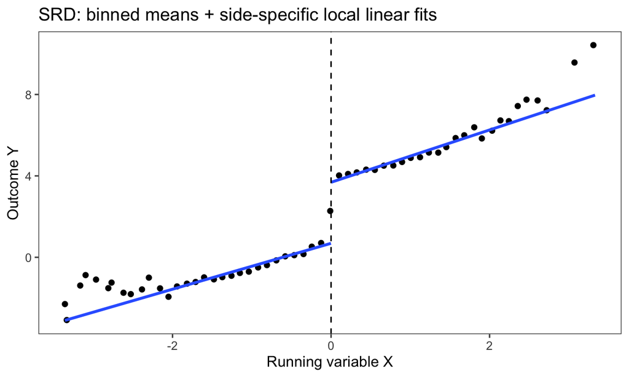

```r
binned <- srd %>%
  mutate(bin = cut(x, breaks = seq(min(x), max(x), length.out = 60))) %>%
  group_by(bin) %>%
  summarize(xbar = mean(x), ybar = mean(y), .groups = "drop")

left  <- dplyr::filter(srd, x <  c0)
right <- dplyr::filter(srd, x >= c0)

p_srd <- ggplot(binned, aes(xbar, ybar)) +
  geom_point() +
  geom_smooth(data = left,  mapping = aes(x = x, y = y), method = "lm", formula = y ~ x, se = FALSE, inherit.aes = FALSE) +
  geom_smooth(data = right, mapping = aes(x = x, y = y), method = "lm", formula = y ~ x, se = FALSE, inherit.aes = FALSE) +
  geom_vline(xintercept = c0, linetype = 2) +
  labs(title = "SRD: binned means + side-specific local linear fits", x = "Running variable X", y = "Outcome Y")
p_srd
```

**What the next chunk does** - Estimates the SRD effect using `rdrobust(y, x, c=)` with **RBC**. - Runs the **`rddensity`** manipulation test and draws the McCrary plot.

**Key functions**: `rdrobust()`, `rddensity()`, `rdplotdensity()`.

```r
est_srd <- rdrobust(yS, x, c = c0, kernel = "triangular", p = 1, q = 2)  # local linear + RBC
summary(est_srd)
```

```
## Sharp RD estimates using local polynomial regression.
##
## Number of Obs.                 4000
## BW type                       mserd
## Kernel                   Triangular
## VCE method                       NN
##
## Number of Obs.                 1998         2002
## Eff. Number of Obs.            1015          997
## Order est. (p)                    1            1
## Order bias  (q)                   2            2
## BW est. (h)                   0.662        0.662
## BW bias (b)                   1.266        1.266
## rho (h/b)                     0.523        0.523
## Unique Obs.                    1998         2002
##
## =====================================================================
##                    Point    Robust Inference
##                 Estimate         z     P>|z|      [ 95% C.I. ]
## ---------------------------------------------------------------------
##      RD Effect     2.828    27.427     0.000     [2.595 , 2.994]
## =====================================================================
```

```r
dens <- rddensity(x, c = c0)
summary(dens)
```

```
##
## Manipulation testing using local polynomial density estimation.
##
## Number of obs =       4000
## Model =               unrestricted
## Kernel =              triangular
## BW method =           estimated
## VCE method =          jackknife
##
## c = 0                 Left of c           Right of c
## Number of obs         1998                2002
## Eff. Number of obs    1226                924
## Order est. (p)        2                   2
## Order bias (q)        3                   3
## BW est. (h)           0.847               0.608
##
## Method                T                   P > |T|
## Robust                -0.0824             0.9343
##
##
## P-values of binomial tests (H0: p=0.5).
##
## Window Length / 2          <c     >=c    P>|T|
## 0.016                      20      35    0.0581
## 0.033                      45      71    0.0199
## 0.049                      73      96    0.0903
## 0.066                     101     121    0.2021
## 0.082                     135     152    0.3450
## 0.098                     164     171    0.7431
## 0.115                     192     194    0.9594
## 0.131                     219     219    1.0000
## 0.147                     245     251    0.8224
## 0.164                     279     273    0.8315
```

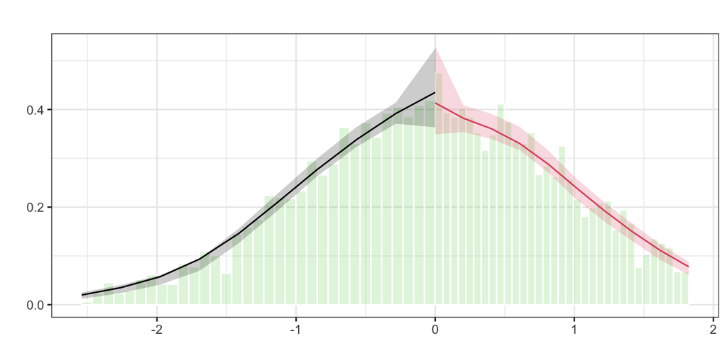

[output not shown]

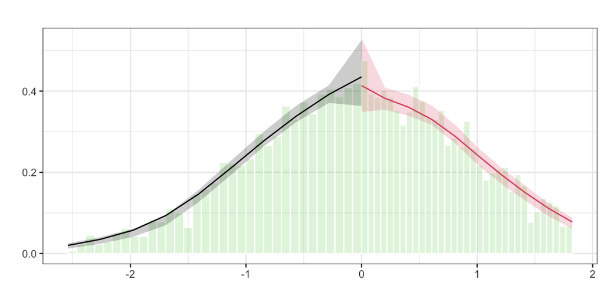

```r
rdplotdensity(dens, x)
```